# My First knitr Document

Global options for the whole document can be set (but later overridden). Common options are:

- results: “asis” or “hide”
- echo: TRUE or FALSE
- fig.height: numeric
- fig.width: numeric

This is some text

Here is a code chunk

```r
set.seed(1)
x <- rnorm(100)
mean(x)
```

```
## [1] 0.1088874
```

Here is a second, named code chunk

```r
y <- rnorm(100)
sd(y)
```

```
## [1] 0.9578791
```

Headlines can also be done like this:

# First header

## second header

Results can also be hidden:

```r
z <- rnorm(100)
z
```

# Output from code can also be added into the text

The current time is Thu Apr 16 6:45:43 AM 2015. My favorite random number is 0.8936737.

# Incorporating Graphics

Let’s first simulate some data.

```r
x <- rnorm(100)
y <- x + rnorm(100, sd = 0.5)
```

Here is a scatterplot of that data. The image of the plot will actually be stored in the file itself.

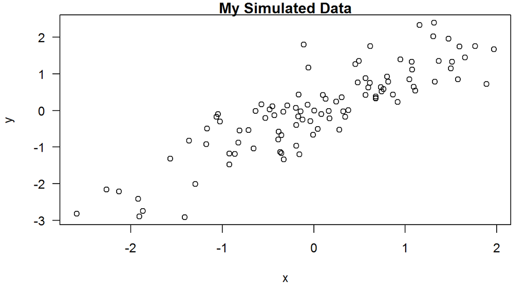

```r
par(mar = c(5,4,1,1), las = 1)
plot(x, y, main = "My Simulated Data")
```

# Making Tables with Xtable

```r
library(datasets)
data(airquality)
fit <- lm(Ozone ~ Wind + Temp + Solar.R, data = airquality)
```

Here is the table of the regression coefficients

```r
library(xtable)
xt <- xtable(summary(fit))
print(xt, type = "html")
```

|  | Estimate | Std. Error | t value | Pr(>\|t\|) |
| --- | --- | --- | --- | --- |
| (Intercept) | -64.3421 | 23.0547 | -2.79 | 0.0062 |
| Wind | -3.3336 | 0.6544 | -5.09 | 0.0000 |
| Temp | 1.6521 | 0.2535 | 6.52 | 0.0000 |
| Solar.R | 0.0598 | 0.0232 | 2.58 | 0.0112 |

# Caching

Computations of the R code can be cached on a chunk by chunk basis. The results are still computed the first time the code is run, but will be stored on the disk. This will save a lot of time for long cumputations. This can be done with the cache=TRUE option.

In this process dependencies are not checked and sometimes chunks have to be rerun automatically. This also needs to happen when external things change (e.g. stored data).

Also chunks with significant side effects can not be cached (e.g. if it modifies something outside of the document).